# anna play

2026-08-06

## Reasons to Hunt by Gender

Not much of a difference between males and females, seem to coincide with their acceptance of hunting.

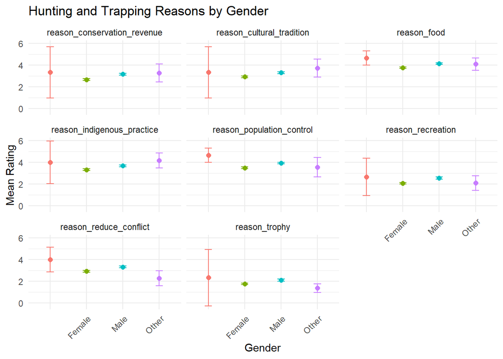

## Methods of Hunting and Trapping

It looks like similar to reasons to hunt, the differences in males and females remains consistent with overall acceptance of hunting.

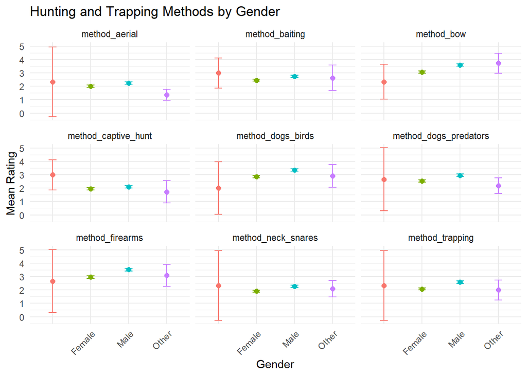

## WVO? Can we break them?

Can we use WVOs to predict acceptance of hunting and trapping?

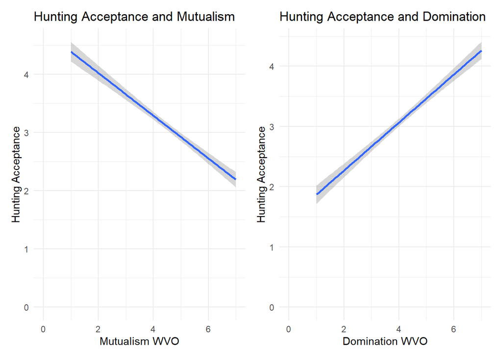

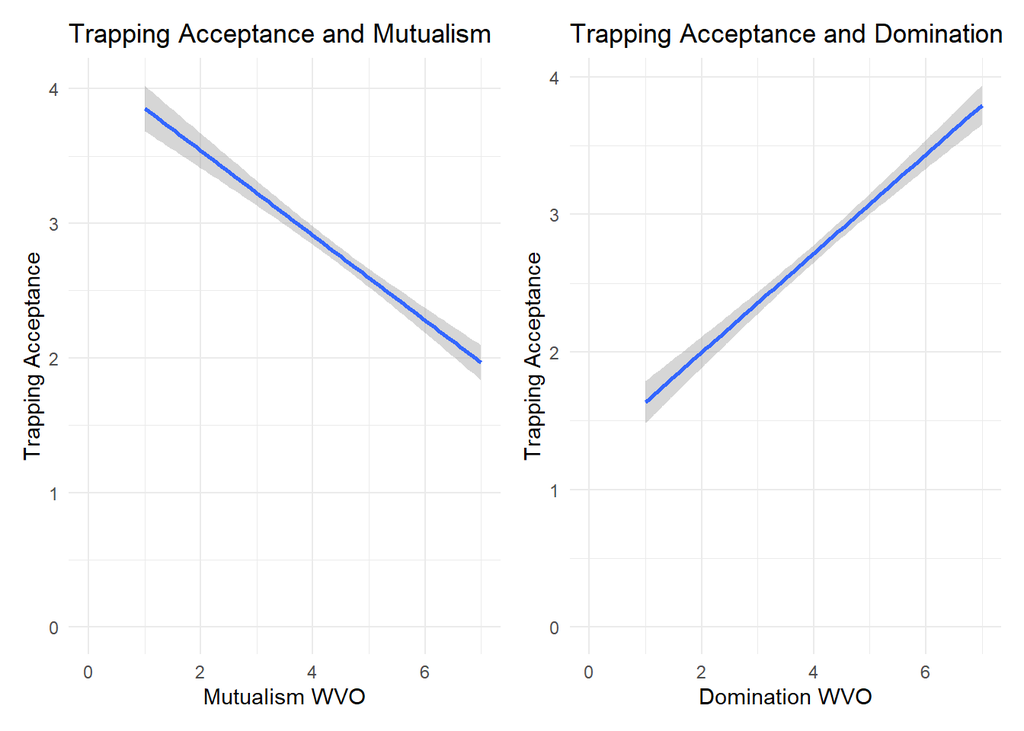

Do WVOs break when asking about acceptance of different species? Or do they remain consistent with the mutualism/domination box?

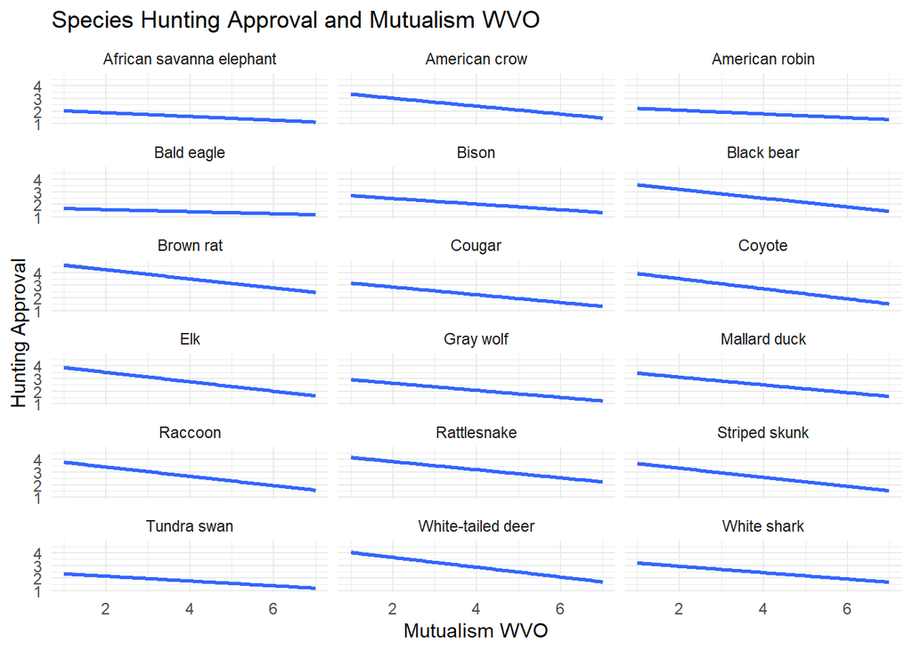

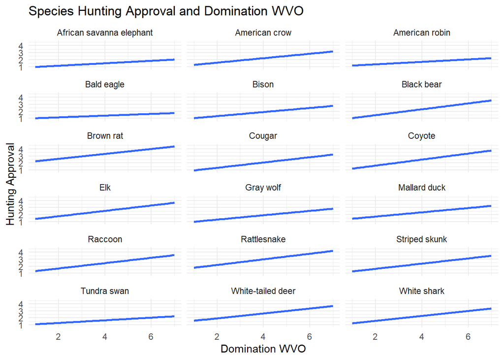

##Species Attitude and Acceptability It looks like for most species as attitude becomes better, acceptability of hunting becomes lower, except for elk and white-tailed deer

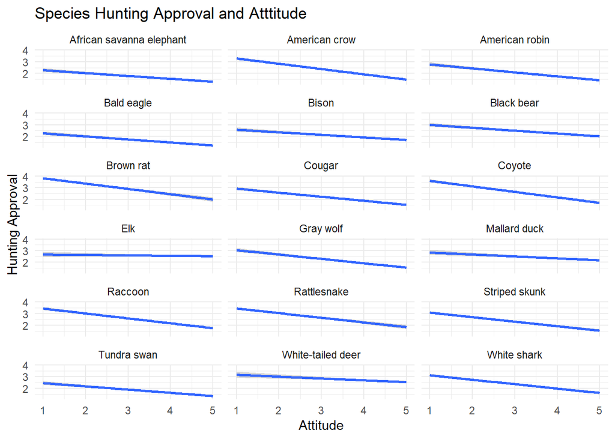

Bald eagle and american robin, it doesn’t matter what their conservation status is, it is always unacceptable to hunt.

The second plot I need someone to check my read on what’s happening. To me it seems like for some species like, elephant, cougar, wolf, rattlesnake, shark, as perceptions of endangerment go down,people’s attitudes towards them go down? Is that what right? Also could be a bad interpretation

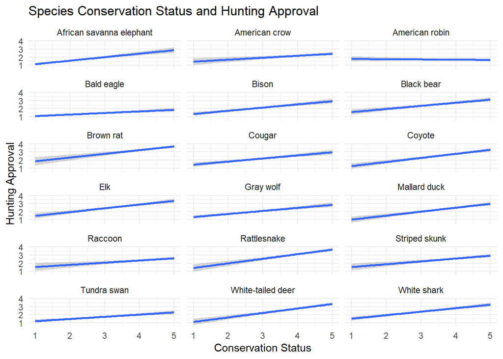

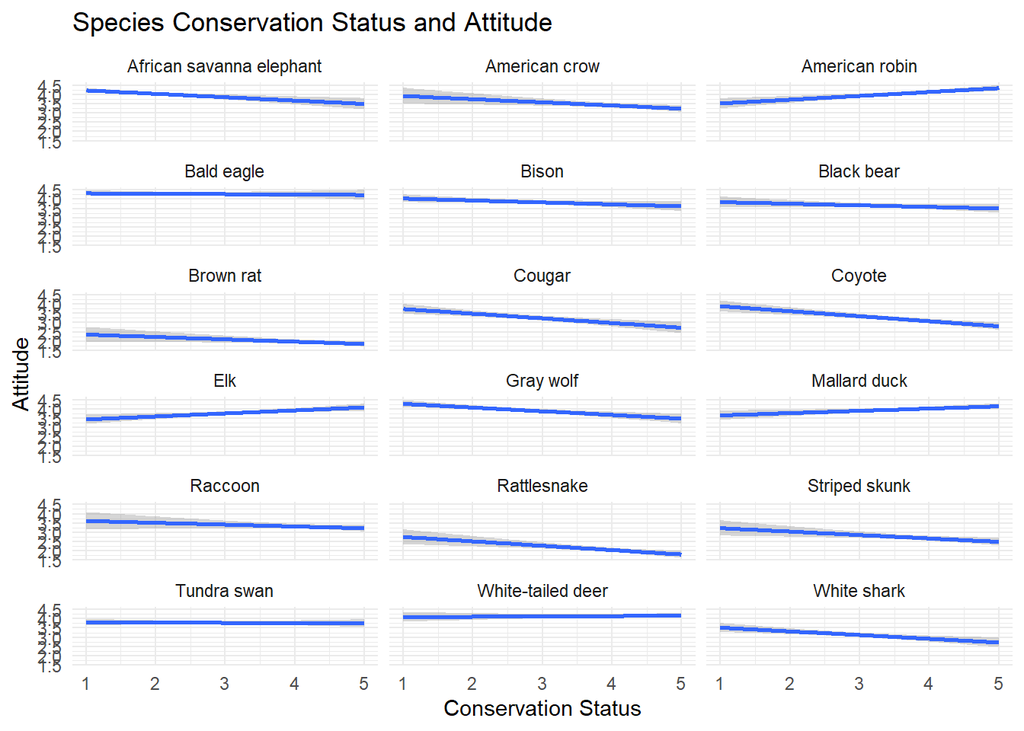

## Back to WVO and Species Characteristics

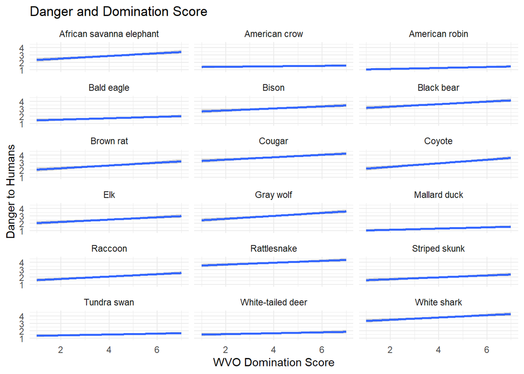

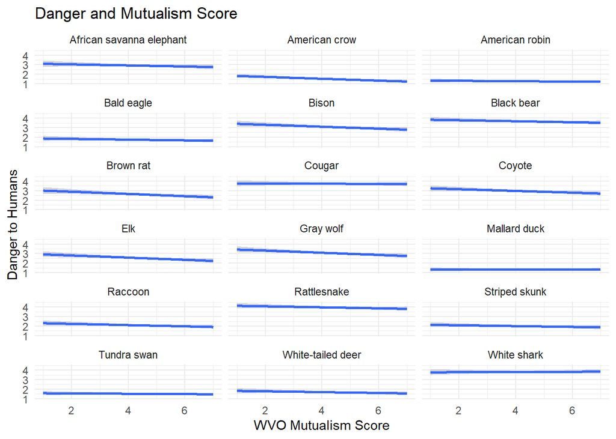